# Statistics: The Science of Decisions Project Instructions

## Background Information

In a Stroop task, participants are presented with a list of words, with each word displayed in a color of ink. The participant’s task is to say out loud the color of the ink in which the word is printed. The task has two conditions: a congruent words condition, and an incongruent words condition. In the congruent words condition, the words being displayed are color words whose names match the colors in which they are printed: for example RED, BLUE. In the incongruent words condition, the words displayed are color words whose names do not match the colors in which they are printed: for example PURPLE, ORANGE. In each case, we measure the time it takes to name the ink colors in equally-sized lists. Each participant will go through and record a time from each condition.

### Questions For Investigation

As a general note, be sure to keep a record of any resources that you use or refer to in the creation of your project. You will need to report your sources as part of the project submission.

```python
import os
from pandas import Series,DataFrame
import pandas
import seaborn as sns
import matplotlib as mpl
import matplotlib.pyplot as plt
import math
import numpy as np
import scipy.stats as stats
import scipy
import pylab
from math import *

path = os.getcwd()
print (path) #Folder Path
```

```
C:\Users\kiang\Downloads\Test-a-Perceptual-Phenomenon-master
```

```python
dframe = pandas.read_csv(path + '/stroopdata.csv')
dframe.head(n=10)
```

|  | Congruent | Incongruent |
| --- | --- | --- |
| 0 | 12.079 | 19.278 |
| 1 | 16.791 | 18.741 |
| 2 | 9.564 | 21.214 |
| 3 | 8.630 | 15.687 |
| 4 | 14.669 | 22.803 |
| 5 | 12.238 | 20.878 |
| 6 | 14.692 | 24.572 |
| 7 | 8.987 | 17.394 |
| 8 | 9.401 | 20.762 |
| 9 | 14.480 | 26.282 |

### 1. What is our independent variable? What is our dependent variable?

Independent variable is a variable (often denoted by x ) whose variation does not depend on that of another.

Dependent variable is a variable (often denoted by y ) whose value depends on that of another.

### 2. What is an appropriate set of hypotheses for this task? What kind of statistical test do you expect to perform? Justify your choices.

μC - Population mean of Congruent Test

μI - Population mean of Incongruent Test

Ho - **Null Hypothesis**: ( μi - μc = 0 || μi = μc ) The population average response time in viewing the congruent(c) words and viewing the incongruent(i) words are equal.

Ha - **Alternative Hypothesis**: ( μi - μc ≠ 0 || μi > μc || μC ≠ μI) Population mean of Incongruent Test will take longer than congruent test.

According to this statistical test, the sample size was below 30 and we don't know the population's standard deviation of this statistical test. If we use t-statistic, it should be dependent sample t-test because it repeated measurements with two conditions. So, t-Test is the most appropriate statistical test to assume the data was random sampled and normal distributed.

### 3. Report some descriptive statistics regarding this dataset. Include at least one measure of central tendency and at least one measure of variability.

```python
meanA = np.mean(dframe['Congruent']); round(meanA,2)
stdA = np.std(dframe['Congruent'])
medianA = np.median(dframe['Congruent'])
rangeA = dframe['Congruent'].max() - dframe['Congruent'].min()
varA = np.var(dframe['Congruent'])


meanB = np.mean(dframe['Incongruent']); round(meanA,2)
stdB = np.std(dframe['Incongruent'])
medianB = np.median(dframe['Incongruent'])
rangeB = dframe['Incongruent'].max() - dframe['Incongruent'].min()
varB= np.var(dframe['Incongruent'])


print('Congruent (Mean): ' + str(round(meanA,4)))
print('Congruent (Standard Deviation): ' + str(round(stdA,4)))
print('Congruent (Median): ' + str(round(medianA,4)))
print('Congruent (Range): ' + str(round(rangeA,4)))
print('Congruent (Variance): ' + str(round(varA,4)) + '\n')

print('Incongruent (Mean): ' + str(round(meanB,4)))
print('Incongruent (Standard Deviation): ' + str(round(stdB,4)))
print('Incongruent (Median): ' + str(round(medianB,4)))
print('Incongruent (Range): ' + str(round(rangeB,4)))
print('Incongruent (Variance): ' + str(round(varB,4)))
dframe.describe()
```

```
Congruent (Mean): 14.0511
Congruent (Standard Deviation): 3.4844
Congruent (Median): 14.3565
Congruent (Range): 13.698
Congruent (Variance): 12.1412

Incongruent (Mean): 22.0159
Incongruent (Standard Deviation): 4.6961
Incongruent (Median): 21.0175
Incongruent (Range): 19.568
Incongruent (Variance): 22.0529
```

|  | Congruent | Incongruent |
| --- | --- | --- |
| count | 24.000000 | 24.000000 |
| mean | 14.051125 | 22.015917 |
| std | 3.559358 | 4.797057 |
| min | 8.630000 | 15.687000 |
| 25% | 11.895250 | 18.716750 |
| 50% | 14.356500 | 21.017500 |
| 75% | 16.200750 | 24.051500 |
| max | 22.328000 | 35.255000 |

### 4. Provide one or two visualizations that show the distribution of the sample data. Write one or two sentences noting what you observe about the plot or plots.

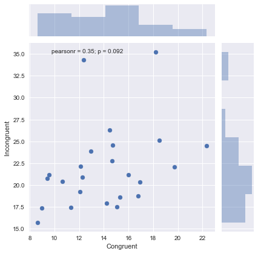

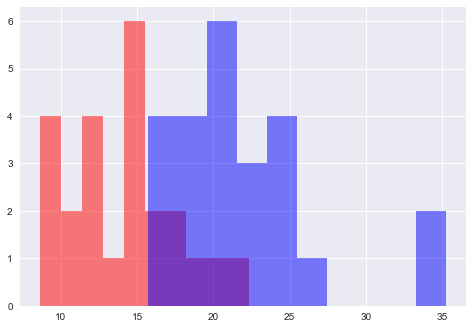

```python
sns.jointplot(dframe['Congruent'],dframe['Incongruent'])
plt.show()


plt.hist(dframe['Congruent'], color='red', alpha=0.5)
plt.hist(dframe['Incongruent'], color='blue',alpha=0.5)
plt.show()
```

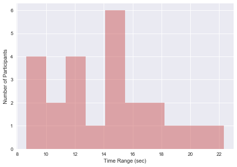

```python
plt.hist(dframe['Congruent'], color='indianred', alpha=0.5)
plt.ylabel('Number of Participants')
plt.xlabel('Time Range (sec)')
plt.show()
```

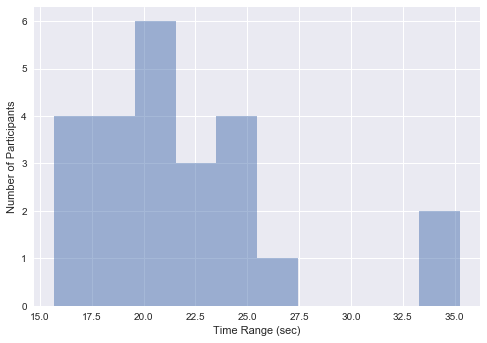

```python
plt.hist(dframe['Incongruent'], alpha=0.5)
plt.ylabel('Number of Participants')
plt.xlabel('Time Range (sec)')
plt.show()
```

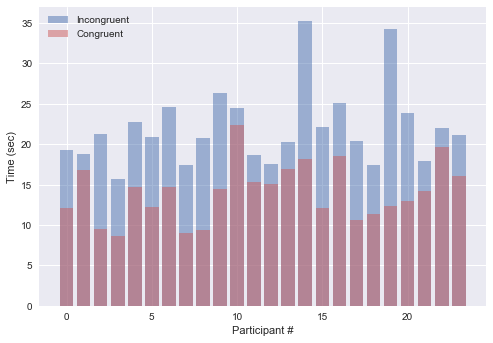

```python
particpants = np.shape(dframe)[0]
x_pos = np.arange(particpants)

plt.bar(x_pos, dframe['Incongruent'], alpha=0.5, label='Incongruent')
plt.bar(x_pos, dframe['Congruent'], color='indianred', alpha=0.5, label='Congruent')
plt.xlabel('Participant #')
plt.ylabel('Time (sec)')
plt.legend()
plt.show()
```

Each participant's congruent time vs their incongruent time.

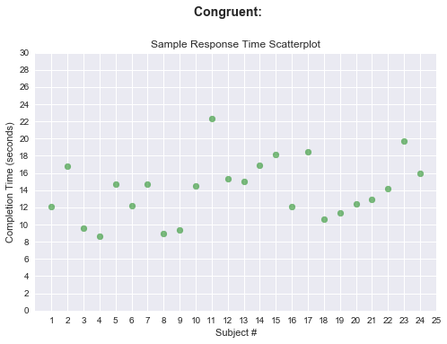

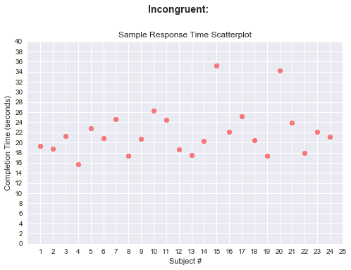

```python
N = len(dframe)
x = range(1,25)
y = dframe['Congruent']
colors = 'green'
area = np.pi * 15 # 0 to 15 point radiuses

fig = plt.figure()
fig.suptitle('Congruent: ', fontsize=14, fontweight='bold')
ax = fig.add_subplot(111)
fig.subplots_adjust(top=0.85)
ax.set_title('Sample Response Time Scatterplot')
ax.set_xlabel('Subject #')
ax.set_ylabel('Completion Time (seconds)')

plt.xticks(np.arange(min(x), max(x)+2, 1.0))
plt.yticks(np.arange(0, 31, 2))
plt.scatter(x, y, s=area, c=colors, alpha=0.5)
plt.ylim([0,30])
plt.xlim([0,25])
plt.show()

N = len(dframe)
x = range(1,25)
y = dframe['Incongruent']
colorsB = 'red'
area = np.pi * 15 # 0 to 15 point radiuses

fig = plt.figure()
fig.suptitle('Incongruent: ', fontsize=14, fontweight='bold')
ax = fig.add_subplot(111)
fig.subplots_adjust(top=0.85)
ax.set_title('Sample Response Time Scatterplot')
ax.set_xlabel('Subject #')
ax.set_ylabel('Completion Time (seconds)')

plt.xticks(np.arange(min(x), max(x)+2, 1.0))
plt.yticks(np.arange(0, 41, 2))
plt.scatter(x, y, s=area, c=colorsB, alpha=0.5)
plt.ylim([0,40])
plt.xlim([0,25])
plt.show()
```

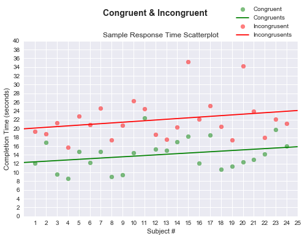

```python
N = len(dframe)
x = range(1,25)
y = dframe['Congruent']
yB = dframe['Incongruent']
colorsA = 'green'
colorsB = 'red'
area = np.pi * 15 # 0 to 15 point radiuses

fig = plt.figure()
fig.suptitle('Congruent & Incongruent ', fontsize=14, fontweight='bold')
ax = fig.add_subplot(111)
fig.subplots_adjust(top=0.85)
ax.set_title('Sample Response Time Scatterplot')
ax.set_xlabel('Subject #')
ax.set_ylabel('Completion Time (seconds)')

plt.xticks(np.arange(min(x), max(x)+2, 1.0))
plt.yticks(np.arange(0, 41, 2))
pointA = plt.scatter(x, y, s=area, c=colorsA, alpha=0.5)
pointB = plt.scatter(x, yB, s=area, c=colorsB, alpha=0.5)


axes = plt.gca()
m, b = np.polyfit(x, y, 1)
X_plot = np.linspace(axes.get_xlim()[0],axes.get_xlim()[1],100)
plotA, = plt.plot(X_plot, m*X_plot + b, '-', color=colorsA)

m, b = np.polyfit(x, yB, 1)
X_plot = np.linspace(axes.get_xlim()[0],axes.get_xlim()[1],100)
plotB, = plt.plot(X_plot, m*X_plot + b, '-',color=colorsB)

plt.legend([pointA,plotA,pointB,plotB],
           ["Congruent","Congruents","Incongrusent","Incongrusents"],
           bbox_to_anchor=(0, 1.225, 1, 0))

plt.ylim([0,40])
plt.xlim([0,25])
plt.show()
```

```python
scipy.stats.shapiro(dframe['Congruent'])
```

```
(0.970922589302063, 0.689803421497345)
```

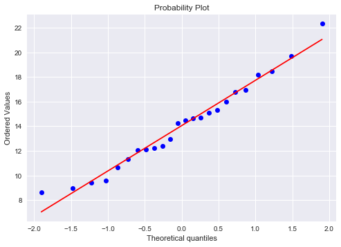

```python
stats.probplot(dframe['Congruent'], dist="norm", plot=pylab) # Test if data is normal distribution using q-q plots
pylab.show()

# Reference http://stackoverflow.com/questions/13865596/quantile-quantile-plot-using-scipy
```

```python
scipy.stats.shapiro(dframe['Incongruent']) #
```

```
(0.85394686460495, 0.0025900385808199644)
```

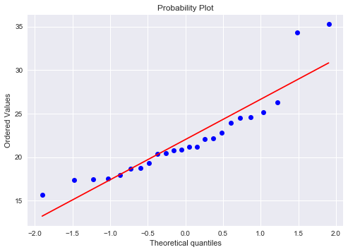

```python
stats.probplot(dframe['Incongruent'], dist="norm", plot=pylab) # Test if data is normal distribution using q-q plots
pylab.show()

# Reference http://stackoverflow.com/questions/13865596/quantile-quantile-plot-using-scipy
```

```
Average difference of 7.964792 with std. dev. of 4.864827.
```

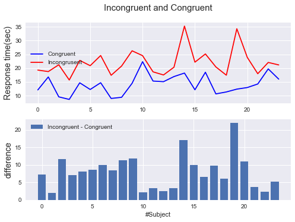

```python
from sklearn.datasets import load_iris
from sklearn.svm import SVC
from sklearn.model_selection import GridSearchCV, cross_val_score, KFold


# Set up possible values of parameters to optimize over
p_grid = {"C": [1, 10, 100],
          "gamma": [.01, .1]}

# We will use a Support Vector Classifier with "rbf" kernel
svr = SVC(kernel="rbf")


difference = dframe['Incongruent'] - dframe['Congruent']

print("Average difference of {0:6f} with std. dev. of {1:6f}."
      .format(difference.mean(), difference.std()))

# Plot scores on each trial for nested and non-nested CV
plt.figure()
plt.subplot(211)
Incongruent_line, = plt.plot(dframe['Incongruent'], color='r')
Congruent_line, = plt.plot(dframe['Congruent'], color='b')
plt.ylabel("Response time(sec)", fontsize="14")
plt.legend([Congruent_line,Incongruent_line],
           ["Congruent","Incongrusent"],
           bbox_to_anchor=(0, .4, .5, 0))
plt.title("Incongruent and Congruent",
          x=.5, y=1.1, fontsize="15")

# Plot bar chart of the difference.
plt.subplot(212)
difference_plot = plt.bar(range(24), difference)
plt.xlabel("#Subject")
plt.legend([difference_plot],
           ["Incongruent - Congruent"],
           bbox_to_anchor=(0, 1, .8, 0))
plt.ylabel("difference", fontsize="14")

plt.show()
```

### 5. Now, perform the statistical test and report your results. What is your confidence level and your critical statistic value? Do you reject the null hypothesis or fail to reject it? Come to a conclusion in terms of the experiment task. Did the results match up with your expectations?

Two tailed t-test

Confidence level : 95%;

Number of subjects in the sample : 24

Degree of freedom(df) = n - 1 = 23

t statistics: 8.020706944109957 (8.0207)

The Cohen'd : 1.6372199491222625 (1.6372)

t critical value: 2.069 (From T-table : https://s3.amazonaws.com/udacity-hosted-downloads/t-table.jpg)

t-statistic > t-critical  
8.0207 > 2.069

We reject the null hypothesis because of the t-statistic value is larger than t-critical value.

```python
n=len(dframe)
```

```python
#point estimate of μi - μc -> PE (in seconds)
PE = meanB - meanA
round(PE,2)
```

```
7.96
```

```python
#s - sample standard deviation of differences
#1. D = sample difference
dframe['Difference'] = dframe['Incongruent'] - dframe['Congruent']
```

```python
#2. DFM = difference from the mean
#SQD = squared differences from the mean
DFM = dframe['Difference'] - dframe['Difference'].mean()
dframe['SQD'] = DFM*DFM
```

```python
#3. SSD = sum of squared differences
SSD = dframe['SQD'].sum()
```

```python
#4. v = variance = SSD/(n-1)
v = SSD/(n-1)
```

```python
#5. s = sqrt(v)
std = sqrt(v)
round(std,2)
```

```
4.86
```

```python
stdError = std / math.sqrt(24)
stdError
```

```
0.9930286347783406
```

```python
#t-statistic
#t = PE/(s/√n)
#PE = (μi - μc)

t = PE/stdError
round(t,4)
```

```
8.0207
```

```python
PE / std
```

```
1.637219949122262
```

```python
PE - (std * 2.068)
```

```
-2.095670383955863
```

```python
t / std
```

```
1.648713734712912
```

```python
(t**2) / ((t**2)+24)
```

```
0.7282969855262733
```

```python
dframe
```

|  | Congruent | Incongruent | Difference | SQD |
| --- | --- | --- | --- | --- |
| 0 | 12.079 | 19.278 | 7.199 | 0.586437 |
| 1 | 16.791 | 18.741 | 1.950 | 36.177719 |
| 2 | 9.564 | 21.214 | 11.650 | 13.580760 |
| 3 | 8.630 | 15.687 | 7.057 | 0.824086 |
| 4 | 14.669 | 22.803 | 8.134 | 0.028631 |
| 5 | 12.238 | 20.878 | 8.640 | 0.455906 |
| 6 | 14.692 | 24.572 | 9.880 | 3.668023 |
| 7 | 8.987 | 17.394 | 8.407 | 0.195548 |
| 8 | 9.401 | 20.762 | 11.361 | 11.534231 |
| 9 | 14.480 | 26.282 | 11.802 | 14.724168 |
| 10 | 22.328 | 24.524 | 2.196 | 33.278957 |
| 11 | 15.298 | 18.644 | 3.346 | 21.333236 |
| 12 | 15.073 | 17.510 | 2.437 | 30.556481 |
| 13 | 16.929 | 20.330 | 3.401 | 20.828194 |
| 14 | 18.200 | 35.255 | 17.055 | 82.631888 |
| 15 | 12.130 | 22.158 | 10.028 | 4.256829 |
| 16 | 18.495 | 25.139 | 6.644 | 1.744491 |
| 17 | 10.639 | 20.429 | 9.790 | 3.331385 |
| 18 | 11.344 | 17.425 | 6.081 | 3.548671 |
| 19 | 12.369 | 34.288 | 21.919 | 194.719930 |
| 20 | 12.944 | 23.894 | 10.950 | 8.911469 |
| 21 | 14.233 | 17.960 | 3.727 | 17.958878 |
| 22 | 19.710 | 22.058 | 2.348 | 31.548349 |
| 23 | 16.004 | 21.157 | 5.153 | 7.906172 |